# Using least squares regression with basis expansion to predict miles per gallon

Janet Prumachuk

We are asked to predict the miles per gallon a car will get using six features about that car. The dataset contains 392 instances of different cars, each containing a 6-dimensional feature vector. Source code for this project is available on [GitHub](https://github.com/jcp1016/MachineLearning/tree/master/1-Regression).

## Data

The dataset was pre-processed such that all features are numeric and have been standardized. There are no missing values.

```r
head(alldata)
```

```
##   mpg intercept_term number_of_cylinders displacement horsepower  weight
## 1  18              1              1.4821       1.0759    0.66329 0.61975
## 2  15              1              1.4821       1.4868    1.57260 0.84226
## 3  18              1              1.4821       1.1810    1.18290 0.53969
## 4  16              1              1.4821       1.0472    1.18290 0.53616
## 5  17              1              1.4821       1.0281    0.92308 0.55500
## 6  15              1              1.4821       2.2418    2.42990 1.60510
##   acceleration model_year
## 1      -1.2836    -1.6232
## 2      -1.4649    -1.6232
## 3      -1.6461    -1.6232
## 4      -1.2836    -1.6232
## 5      -1.8273    -1.6232
## 6      -2.0086    -1.6232
```

## Part 1 - Simple Linear Regression

1. We randomly split the dataset into 372 training examples and 20 testing examples. Using the training data only, we fit a linear regression model using least squares and show the model coefficients.

```
##                     Coefficient
## intercept_term      23.46688382
## number_of_cylinders -0.37696482
## displacement         0.74068258
## horsepower           0.01711253
## weight              -5.85291105
## acceleration         0.24104586
## model_year           2.79746087
```

The signs tell us the following about the training set:  
A negative sign indicates that as the value of the feature increased, mpg decreased.  
A positive sign indicates that as the value of the feature increased, mpg increased.

2. We repeat the process of randomly splitting into training and testing sets 1000 times. Each time we use the training set to fit a least squares regression model, and each time we use the resulting model to predict mpg for each car in the testing set. We check our results by calculating the root mean squared error (RMSE) of the predictions and we calculate the mean and standard deviation of the 1000 RMSEs.

```
##  p MeanRMSE StdDevRMSE MeanPredError StdDevPredError LogLikelihood
##  1 3.438129  0.7066084    0.01679834        3.509949     -19527.42
```

## Part 2 - Linear Regression with Basis Expansion

Next we see if performance can be improved by fitting a *p*th order regression model using least squares for p = 1,2,3,4. This is also known as linear regression with basis expansion. Although we are introducing polynomial terms, the model is still linear in the *coefficients*. For each value of p, we run 1000 experiments on randomly partitioned training/testing sets using 372 training and 20 testing examples.

1. For each experiment we calculate the root mean squared error (RMSE) and for each p we plot a histogram of the prediction errors. We can then determine which p is best.

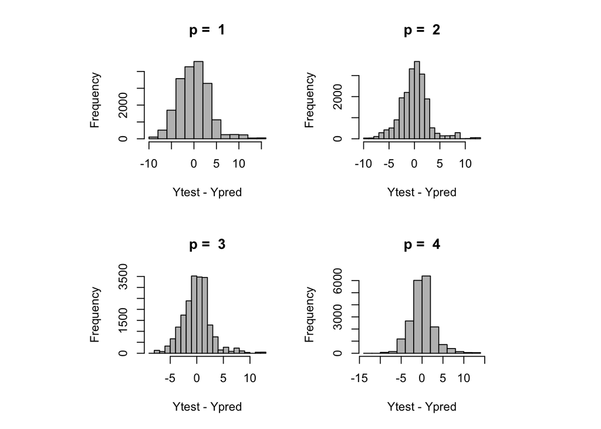

```
##  p MeanRMSE StdDevRMSE MeanPredError StdDevPredError LogLikelihood
##  1 3.424022  0.6618069  0.0001519305        3.487394     -19560.01
##  2 2.771984  0.6236388 -0.0096561883        2.841254     -19614.52
##  3 2.614862  0.5973295 -0.0193335491        2.682151     -19549.50
##  4 2.731760  0.6333543  0.0319045263        2.804039     -19575.42
```

The prediction errors tell us how well the model performed against the test sets. The closer the mean RMSE is to zero, the closer the fit. A smaller RMSE standard deviation indicates that the errors are more concentrated around the mean. Consequently the model for p = 3 appears to fit best out of the four, because its mean RMSE is closest to zero. The RMSE standard deviation for p = 3 is also slightly smaller than the others. This can also be seen in the histograms.

2. We are asked to use maximum likelihood to fit a univariate Gaussian to the 20,000 errors and compute the log likelihood of these empirical errors using the maximum liklihood estimates (MLE) for mean and variance. The MLE for the mean of a Gaussian distribution is the sample mean. The MLE for the variance is the empirical sample variance. To compute the log likelihood of the empirical prediction errors I used the R function *pnorm* on the prediction errors with mean = the mean prediction error, sd = the standard deviation of the prediction errors, and setting the log option to TRUE. Then I simply summed the resulting log probabilities because maximum likelihood estimation assumes the most reasonable values are those for which the probability of the observed sample is largest.

For p=3 the prediction errors have the largest log-likelihood, indicating that its prediction errors are more likely than the other three models to come from a Gaussian distribution with mean equal to the mean prediction error and variance equal to the prediction error variance.

The assumption best satisfied by p=3 in this set of experiments is that there is a linear relationship between mpg (y) and the expanded feature set (X). This is best supported when the unexplained part of the relationship, the prediction errors, have a Gaussian distribution with parameters mu equal to the sample mean and sigma-squared equal to the sample variance.

## References

Trevor Hastie, Robert Tibshirani, Jerome Friedman, The Elements of Statistical Learning, Second Edition, (New York: Springer, 2009)